# Machine Learning: AllLife Bank Personal Loan Campaign

#### Decision Tree (Post-pruning)

```python
# Create an instance of the decision tree model
clf = DecisionTreeClassifier(class_weight='balanced',random_state=RS)

# Compute the cost complexity pruning path for the model using the training data
path = clf.cost_complexity_pruning_path(X_train, y_train)

# Extract the array of effective alphas from the pruning path
ccp_alphas = abs(path.ccp_alphas)

# Extract the array of total impurities at each alpha along the pruning path
impurities = path.impurities

pd.DataFrame(path)
```

|  | ccp_alphas | impurities |
| --- | --- | --- |
| 0 | 0.000000e+00 | -1.079812e-16 |
| 1 | 1.543926e-18 | -1.064373e-16 |
| 2 | 1.543926e-18 | -1.048934e-16 |
| 3 | 1.543926e-18 | -1.033495e-16 |
| 4 | 1.543926e-18 | -1.018055e-16 |
| 5 | 1.982541e-18 | -9.982299e-17 |
| 6 | 2.052720e-18 | -9.777027e-17 |
| 7 | 2.210621e-18 | -9.555965e-17 |
| 8 | 2.643388e-18 | -9.291626e-17 |
| 9 | 3.473833e-18 | -8.944243e-17 |
| 10 | 1.652118e-17 | -7.292125e-17 |
| 11 | 1.945347e-16 | 1.216134e-16 |
| 12 | 2.757136e-16 | 3.973270e-16 |
| 13 | 8.923540e-16 | 1.289681e-15 |
| 14 | 1.526252e-04 | 3.052503e-04 |
| 15 | 1.539409e-04 | 6.131321e-04 |
| 16 | 1.567474e-04 | 9.266268e-04 |
| 17 | 1.621448e-04 | 1.250916e-03 |
| 18 | 2.105024e-04 | 1.882424e-03 |
| 19 | 2.857143e-04 | 2.168138e-03 |
| 20 | 2.923583e-04 | 2.460496e-03 |
| 21 | 2.995079e-04 | 5.455575e-03 |
| 22 | 3.001200e-04 | 5.755695e-03 |
| 23 | 3.001200e-04 | 6.656055e-03 |
| 24 | 3.052503e-04 | 6.961305e-03 |
| 25 | 3.078818e-04 | 7.269187e-03 |
| 26 | 3.078818e-04 | 7.577069e-03 |
| 27 | 4.234896e-04 | 1.011801e-02 |
| 28 | 4.722795e-04 | 1.106257e-02 |
| 29 | 4.927086e-04 | 1.155527e-02 |
| 30 | 5.426170e-04 | 1.209789e-02 |
| 31 | 5.436038e-04 | 1.318510e-02 |
| 32 | 5.703384e-04 | 1.375544e-02 |
| 33 | 7.434819e-04 | 1.672936e-02 |
| 34 | 8.479100e-04 | 1.842518e-02 |
| 35 | 1.030488e-03 | 2.048616e-02 |
| 36 | 1.099864e-03 | 2.158602e-02 |
| 37 | 1.132588e-03 | 2.385120e-02 |
| 38 | 1.603499e-03 | 2.545470e-02 |
| 39 | 1.724472e-03 | 2.717917e-02 |
| 40 | 1.784924e-03 | 2.896410e-02 |
| 41 | 1.793666e-03 | 3.434509e-02 |
| 42 | 2.032423e-03 | 3.840994e-02 |
| 43 | 2.186703e-03 | 4.059664e-02 |
| 44 | 2.962264e-03 | 4.355891e-02 |
| 45 | 5.593362e-03 | 4.915227e-02 |
| 46 | 5.872977e-03 | 5.502525e-02 |
| 47 | 6.618052e-03 | 6.164330e-02 |
| 48 | 6.913702e-03 | 6.855700e-02 |
| 49 | 7.489143e-03 | 7.604614e-02 |
| 50 | 2.867322e-02 | 1.047194e-01 |
| 51 | 5.478478e-02 | 2.142889e-01 |
| 52 | 2.857111e-01 | 5.000000e-01 |

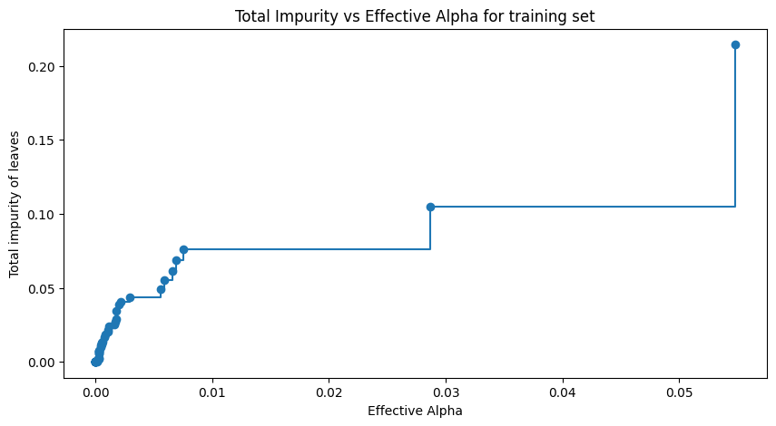

```python
# Create a figure
fig, ax = plt.subplots(figsize=(10, 5))

# Plot the total impurities versus effective alphas, excluding the last value,
# using markers at each data point and connecting them with steps
ax.plot(ccp_alphas[:-1], impurities[:-1], marker="o", drawstyle="steps-post")

# Set the x-axis label
ax.set_xlabel("Effective Alpha")

# Set the y-axis label
ax.set_ylabel("Total impurity of leaves")

# Set the title of the plot
ax.set_title("Total Impurity vs Effective Alpha for training set");
```

Next, we train a decision tree using the effective alphas. The last value in `ccp_alphas` is the alpha value that prunes the whole tree, leaving the tree, `clfs[-1]`, with one node.

```python
# Initialize an empty list to store the decision tree classifiers
clfs = []

# Iterate over each ccp_alpha value extracted from cost complexity pruning path
for ccp_alpha in ccp_alphas:
    # Create an instance of the DecisionTreeClassifier
    clf = DecisionTreeClassifier(class_weight='balanced',ccp_alpha=ccp_alpha, random_state=RS)

    # Fit the classifier to the training data
    clf.fit(X_train, y_train)

    # Append the trained classifier to the list
    clfs.append(clf)

# Print the number of nodes in the last tree along with its ccp_alpha value
print(
    "Number of nodes in the last tree is {} with ccp_alpha {}".format(
        clfs[-1].tree_.node_count, ccp_alphas[-1]
    )
)
```

```
Number of nodes in the last tree is 1 with ccp_alpha 0.2857110844037627
```

For the remainder, we remove the last element in `clfs` and `ccp_alphas`, because it is the trivial tree with only one node. Here we show that the number of nodes and tree depth decreases as alpha increases.

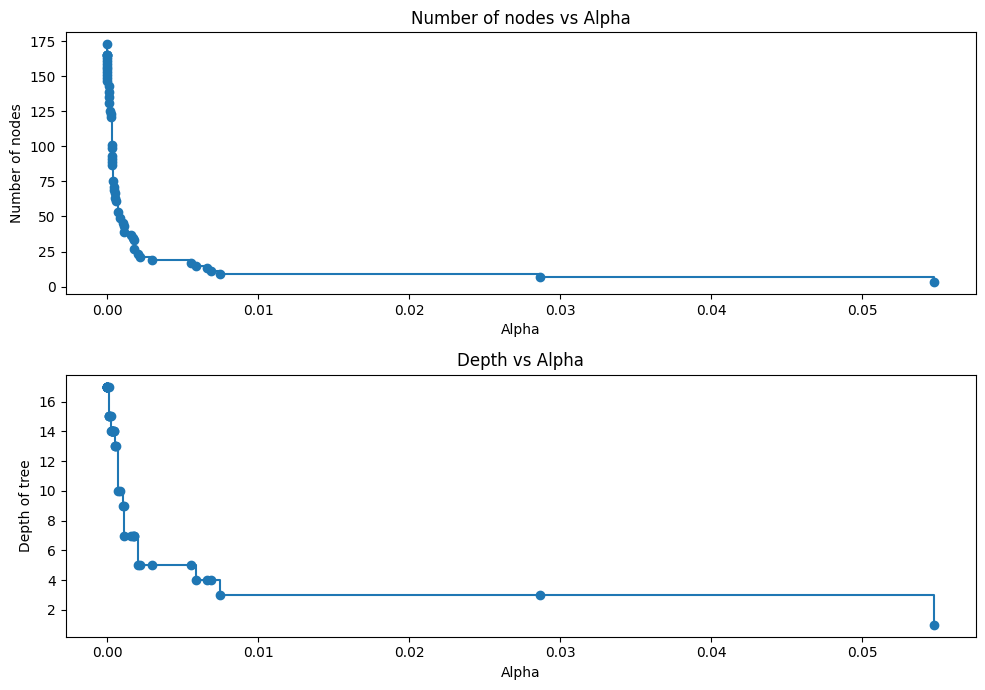

```python
# Remove the last classifier and corresponding ccp_alpha value from the lists
clfs = clfs[:-1]
ccp_alphas = ccp_alphas[:-1]

# Extract the number of nodes in each tree classifier
node_counts = [clf.tree_.node_count for clf in clfs]

# Extract the maximum depth of each tree classifier
depth = [clf.tree_.max_depth for clf in clfs]

# Create a figure and a set of subplots
fig, ax = plt.subplots(2, 1, figsize=(10, 7))

# Plot the number of nodes versus ccp_alphas on the first subplot
ax[0].plot(ccp_alphas, node_counts, marker="o", drawstyle="steps-post")
ax[0].set_xlabel("Alpha")
ax[0].set_ylabel("Number of nodes")
ax[0].set_title("Number of nodes vs Alpha")

# Plot the depth of tree versus ccp_alphas on the second subplot
ax[1].plot(ccp_alphas, depth, marker="o", drawstyle="steps-post")
ax[1].set_xlabel("Alpha")
ax[1].set_ylabel("Depth of tree")
ax[1].set_title("Depth vs Alpha")

# Adjust the layout of the subplots to avoid overlap
fig.tight_layout()
```

```python
train_f1_scores = []  # Initialize an empty list to store F1 scores for training set for each decision tree classifier

# Iterate through each decision tree classifier in 'clfs'
for clf in clfs:
    # Predict labels for the training set using the current decision tree classifier
    pred_train = clf.predict(X_train)

    # Calculate the F1 score for the training set predictions compared to true labels
    f1_train = recall_score(y_train, pred_train)

    # Append the calculated F1 score to the train_f1_scores list
    train_f1_scores.append(f1_train)
```

```python
test_f1_scores = []  # Initialize an empty list to store F1 scores for test set for each decision tree classifier

# Iterate through each decision tree classifier in 'clfs'
for clf in clfs:
    # Predict labels for the test set using the current decision tree classifier
    pred_test = clf.predict(X_test)

    # Calculate the F1 score for the test set predictions compared to true labels
    f1_test = recall_score(y_test, pred_test)

    # Append the calculated F1 score to the test_f1_scores list
    test_f1_scores.append(f1_test)
```

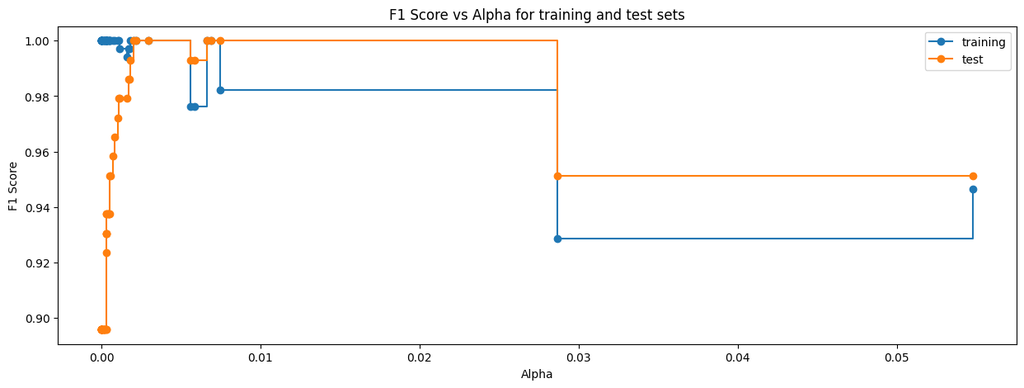

```python
# Create a figure
fig, ax = plt.subplots(figsize=(15, 5))
ax.set_xlabel("Alpha")  # Set the label for the x-axis
ax.set_ylabel("F1 Score")  # Set the label for the y-axis
ax.set_title("F1 Score vs Alpha for training and test sets")  # Set the title of the plot

# Plot the training F1 scores against alpha, using circles as markers and steps-post style
ax.plot(ccp_alphas, train_f1_scores, marker="o", label="training", drawstyle="steps-post")

# Plot the testing F1 scores against alpha, using circles as markers and steps-post style
ax.plot(ccp_alphas, test_f1_scores, marker="o", label="test", drawstyle="steps-post")

ax.legend();  # Add a legend to the plot
```

```python
# creating the model where we get highest test F1 Score
postprun_best_model = np.argmax(test_f1_scores)

# selcting the decision tree model corresponding to the highest test score
postpruned_dt = clfs[postprun_best_model]
print(postpruned_dt)
```

```
DecisionTreeClassifier(ccp_alpha=0.0020324228398762266, class_weight='balanced',
                       random_state=42)
```

#### Model Evaluation

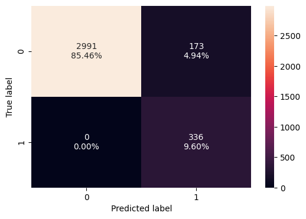

```python
plot_confusion_matrix(postpruned_dt, X_train, y_train)
```

```python
postprun_loan_dt_train_matrices = model_performance_classification(postpruned_dt, X_train, y_train)
postprun_loan_dt_train_matrices
```

|  | Accuracy | Recall | Precision | F1 |
| --- | --- | --- | --- | --- |
| 0 | 0.950571 | 1.0 | 0.660118 | 0.795266 |

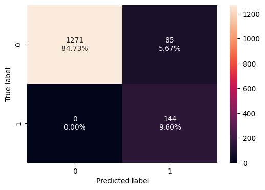

```python
plot_confusion_matrix(postpruned_dt, X_test, y_test)
```

```python
postprun_loan_dt_test_matrices = model_performance_classification(postpruned_dt, X_test, y_test)
postprun_loan_dt_test_matrices
```

|  | Accuracy | Recall | Precision | F1 |
| --- | --- | --- | --- | --- |
| 0 | 0.943333 | 1.0 | 0.628821 | 0.772118 |

- After post pruning the model performance improved for Recall but decrease in Accuray and Precision. But the model has become simpler.

#### Visualizing Decision Tree

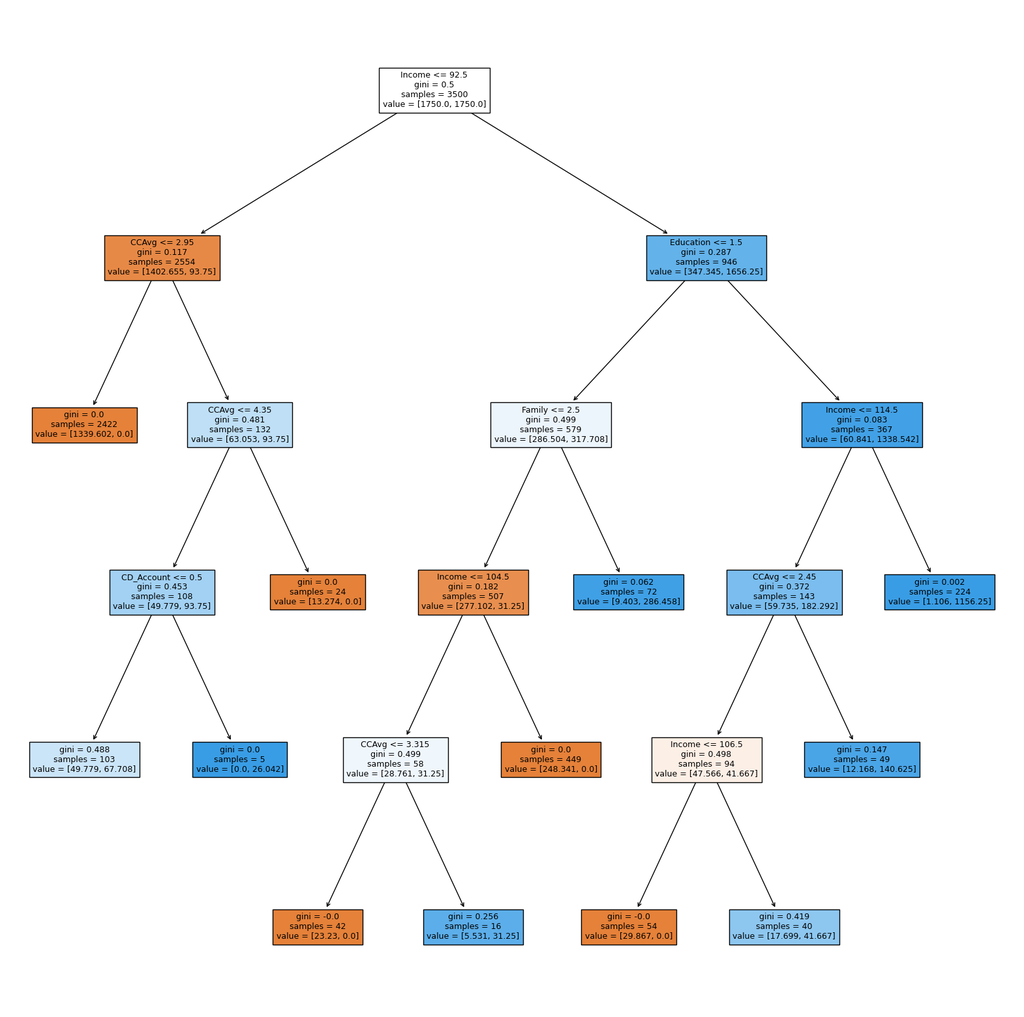

```python
plot_decision_tree(postpruned_dt,X_train)
```

```python
print_text_report(postpruned_dt,  X_train)
```

```
|--- Income <= 92.50
|   |--- CCAvg <= 2.95
|   |   |--- weights: [1339.60, 0.00] class: 0
|   |--- CCAvg >  2.95
|   |   |--- CCAvg <= 4.35
|   |   |   |--- CD_Account <= 0.50
|   |   |   |   |--- weights: [49.78, 67.71] class: 1
|   |   |   |--- CD_Account >  0.50
|   |   |   |   |--- weights: [0.00, 26.04] class: 1
|   |   |--- CCAvg >  4.35
|   |   |   |--- weights: [13.27, 0.00] class: 0
|--- Income >  92.50
|   |--- Education <= 1.50
|   |   |--- Family <= 2.50
|   |   |   |--- Income <= 104.50
|   |   |   |   |--- CCAvg <= 3.31
|   |   |   |   |   |--- weights: [23.23, 0.00] class: 0
|   |   |   |   |--- CCAvg >  3.31
|   |   |   |   |   |--- weights: [5.53, 31.25] class: 1
|   |   |   |--- Income >  104.50
|   |   |   |   |--- weights: [248.34, 0.00] class: 0
|   |   |--- Family >  2.50
|   |   |   |--- weights: [9.40, 286.46] class: 1
|   |--- Education >  1.50
|   |   |--- Income <= 114.50
|   |   |   |--- CCAvg <= 2.45
|   |   |   |   |--- Income <= 106.50
|   |   |   |   |   |--- weights: [29.87, 0.00] class: 0
|   |   |   |   |--- Income >  106.50
|   |   |   |   |   |--- weights: [17.70, 41.67] class: 1
|   |   |   |--- CCAvg >  2.45
|   |   |   |   |--- weights: [12.17, 140.62] class: 1
|   |   |--- Income >  114.50
|   |   |   |--- weights: [1.11, 1156.25] class: 1
```